# Confirmatory factor analysis of MASQ anhedonia, GAD-7 and PHQ-9 in RAMP baseline data

K L Purves

27 September, 2021

This workbook will conduct the factor analysis of MASQ, GAD and PHQ-9 data in RAMP baseline to establish whether it corresponds to a three factor model, corresponding to the tripartite theory.

# Set up

```r
#remove(list = ls())
```

Note: load tidyverse last!

```r
if(!require(summarytools)){
  install.packages("summarytools")
  library(summarytools)
}
```

```
For best results, restart R session and update pander using devtools:: or remotes::install_github('rapporter/pander')
```

```r
if(!require(ggplot2)){
  install.packages("ggplot2")
  library(ggplot2)
}
if(!require(psych)){
  install.packages("psych")
  library(psych)
}
if(!require(tidyverse)){
  install.packages("tidyverse")
  library(tidyverse)
}
```

```
x psych::%+%()    masks ggplot2::%+%()
```

```r
if(!require(skimr)){
  install.packages("skimr")
  library(skimr)
}
if(!require(lavaan)){
  install.packages("lavaan")
  library(lavaan)
}
if(!require(reshape2)){
  install.packages("reshape2")
  library(reshape2)
}
```

```r
# if(!require(geom_text)){
#   install.packages("geom_text")
#   library(geom_text)
# }
```

```r
glad_palette = c("#efc00b", "#b7dee8")
```

# Read in data

```r
# Read in the data
MASQ <- readRDS(file =  "../../../data_clean/masq/masq.clean_baseline_items.RAMP_notrecoded.RDS")
GAD7 <- readRDS(file =  "../../../data_clean/gad/gad.clean_baseline_items.RAMP.RDS")
PHQ9 <- readRDS(file =  "../../../data_clean/phq/phq.clean_baseline_items.RAMP.RDS")
```

# reverse MASQ scores to be in line with GAD & PHQ

also make -77 NA

```r
MASQ.recode <- MASQ %>%
  mutate_at(vars(starts_with("masq")),
            funs(case_when(
             . == 1 ~ 5,
             . == 2 ~ 4,
             . == 3 ~ 3,
             . == 4 ~ 2,
             . == 5 ~ 1,
             . == -77 ~ NA_real_,
             TRUE ~  NA_real_)))
```

# merge MASQ, PHQ and GAD data

```r
merged_data <- left_join(GAD7,PHQ9)
merged_data <- left_join(merged_data,MASQ.recode)
```

## check data names and dimensions

```r
head(merged_data)
```

| ID | gad7.pandemic_nervous_anxious_on_edge_.Wave_0 | gad7.pandemic_cant_control_worry_.Wave_0 | gad7.pandemic_worry_too_much_.Wave_0 | gad7.pandemic_trouble_relaxing_.Wave_0 | gad7.pandemic_restless_.Wave_0 | gad7.pandemic_easily_annoyed_.Wave_0 | gad7.pandemic_afraid_something_terrible_will_happen_.Wave_0 | phq9.pandemic_little_interest_or_pleasure_.Wave_0 | phq9.pandemic_down_depressed_hopeless_.Wave_0 | phq9.pandemic_trouble_falling_or_staying_asleep_.Wave_0 | phq9.pandemic_feel_tired_little_energy_.Wave_0 | phq9.pandemic_poor_appetite_or_overeating_.Wave_0 | phq9.pandemic_feeling_like_a_failure_.Wave_0 | phq9.pandemic_trouble_concentrating_.Wave_0 | phq9.pandemic_fidgeting_or_moving_slowly_.Wave_0 | phq9.pandemic_thoughts_better_off_dead_.Wave_0 | startDate | endDate | masq.pandemic_felt_successful_.Wave_0 | masq.pandemic_felt_really_happy_.Wave_0 | masq.pandemic_felt_optimistic_.Wave_0 | masq.pandemic_lot_felt_fun_.Wave_0 | masq.pandemic_felt_like_i_accomplished_a_lot_.Wave_0 | masq.pandemic_forward_lot_felt_.Wave_0 | masq.pandemic_felt_really_talkative_.Wave_0 | masq.pandemic_felt_really_up_or_lively_.Wave_0 | masq.pandemic_lot_felt_energy_.Wave_0 | masq.pandemic_felt_really_good_about_myself_.Wave_0 |
| --- | --- | --- | --- | --- | --- | --- | --- | --- | --- | --- | --- | --- | --- | --- | --- | --- | --- | --- | --- | --- | --- | --- | --- | --- | --- | --- | --- | --- |
| b505a12db9cf8b09b0a7b82eb954 | 1 | 1 | 1 | 0 | 0 | 2 | 0 | 0 | 0 | 0 | 0 | 0 | 0 | 0 | 0 | 0 | 2020-04-07 12:54:24 | 2020-04-07 13:19:13 | 2 | 2 | 2 | 2 | 4 | 4 | 2 | 2 | 2 | 2 |
| 434c2f755f0d3894f5c0fe30e977 | 0 | 0 | 1 | 0 | 0 | 2 | 0 | 1 | 1 | 2 | 2 | 1 | 1 | 0 | 0 | 0 | 2020-04-07 13:01:00 | 2020-04-07 13:50:39 | 2 | 4 | 4 | 5 | 5 | 5 | 5 | 5 | 5 | 5 |
| f5ccde980081f67c4f27335c5c1a | 3 | 2 | 3 | 2 | 1 | 0 | 2 | 2 | 1 | 2 | 1 | 0 | 1 | 2 | 0 | 0 | 2020-04-07 13:00:18 | 2020-04-07 13:53:50 | 4 | 4 | 4 | 4 | 3 | 3 | 3 | 4 | 3 | 3 |
| 86c27596d5e05bb0695ae99081c4 | 3 | 2 | 2 | 2 | 1 | 3 | 1 | 3 | 2 | 1 | 1 | 0 | 2 | 2 | 0 | 0 | 2020-04-07 13:27:14 | 2020-04-07 14:11:15 | 5 | 3 | 3 | 4 | 5 | 3 | 4 | 3 | 4 | 4 |
| 8e6d3429777bd1407a9a0fe6257b | 2 | 2 | 2 | 2 | 2 | 3 | 2 | 1 | 2 | 2 | 3 | 2 | 3 | 2 | 1 | 2 | 2020-04-07 13:36:56 | 2020-04-07 14:39:45 | 4 | 3 | 3 | 4 | 3 | 4 | 4 | 4 | 5 | 4 |
| 4884245a2c3a47081b222df1d090 | 0 | 0 | 0 | 0 | 0 | 0 | 0 | 0 | 0 | 1 | 1 | 0 | 0 | 0 | 0 | 0 | 2020-04-07 14:23:12 | 2020-04-07 14:44:51 | 2 | 3 | 3 | 2 | 4 | 4 | 2 | 2 | 3 | 3 |

```r
names(merged_data)
```

```
 [1] "ID"
 [2] "gad7.pandemic_nervous_anxious_on_edge_.Wave_0"
 [3] "gad7.pandemic_cant_control_worry_.Wave_0"
 [4] "gad7.pandemic_worry_too_much_.Wave_0"
 [5] "gad7.pandemic_trouble_relaxing_.Wave_0"
 [6] "gad7.pandemic_restless_.Wave_0"
 [7] "gad7.pandemic_easily_annoyed_.Wave_0"
 [8] "gad7.pandemic_afraid_something_terrible_will_happen_.Wave_0"
 [9] "phq9.pandemic_little_interest_or_pleasure_.Wave_0"
[10] "phq9.pandemic_down_depressed_hopeless_.Wave_0"
[11] "phq9.pandemic_trouble_falling_or_staying_asleep_.Wave_0"
[12] "phq9.pandemic_feel_tired_little_energy_.Wave_0"
[13] "phq9.pandemic_poor_appetite_or_overeating_.Wave_0"
[14] "phq9.pandemic_feeling_like_a_failure_.Wave_0"
[15] "phq9.pandemic_trouble_concentrating_.Wave_0"
[16] "phq9.pandemic_fidgeting_or_moving_slowly_.Wave_0"
[17] "phq9.pandemic_thoughts_better_off_dead_.Wave_0"
[18] "startDate"
[19] "endDate"
[20] "masq.pandemic_felt_successful_.Wave_0"
[21] "masq.pandemic_felt_really_happy_.Wave_0"
[22] "masq.pandemic_felt_optimistic_.Wave_0"
[23] "masq.pandemic_lot_felt_fun_.Wave_0"
[24] "masq.pandemic_felt_like_i_accomplished_a_lot_.Wave_0"
[25] "masq.pandemic_forward_lot_felt_.Wave_0"
[26] "masq.pandemic_felt_really_talkative_.Wave_0"
[27] "masq.pandemic_felt_really_up_or_lively_.Wave_0"
[28] "masq.pandemic_lot_felt_energy_.Wave_0"
[29] "masq.pandemic_felt_really_good_about_myself_.Wave_0"
```

```r
dim(merged_data)
```

```
[1] 10900    29
```

# drop uneccessary columns, blanks and duplicates

```r
cfa_data.clean <- merged_data %>% #new dataset with ID
  drop_na(ID) %>% # Drop NAs
  select(-c(startDate,endDate))

names(cfa_data.clean)
```

```
 [1] "ID"
 [2] "gad7.pandemic_nervous_anxious_on_edge_.Wave_0"
 [3] "gad7.pandemic_cant_control_worry_.Wave_0"
 [4] "gad7.pandemic_worry_too_much_.Wave_0"
 [5] "gad7.pandemic_trouble_relaxing_.Wave_0"
 [6] "gad7.pandemic_restless_.Wave_0"
 [7] "gad7.pandemic_easily_annoyed_.Wave_0"
 [8] "gad7.pandemic_afraid_something_terrible_will_happen_.Wave_0"
 [9] "phq9.pandemic_little_interest_or_pleasure_.Wave_0"
[10] "phq9.pandemic_down_depressed_hopeless_.Wave_0"
[11] "phq9.pandemic_trouble_falling_or_staying_asleep_.Wave_0"
[12] "phq9.pandemic_feel_tired_little_energy_.Wave_0"
[13] "phq9.pandemic_poor_appetite_or_overeating_.Wave_0"
[14] "phq9.pandemic_feeling_like_a_failure_.Wave_0"
[15] "phq9.pandemic_trouble_concentrating_.Wave_0"
[16] "phq9.pandemic_fidgeting_or_moving_slowly_.Wave_0"
[17] "phq9.pandemic_thoughts_better_off_dead_.Wave_0"
[18] "masq.pandemic_felt_successful_.Wave_0"
[19] "masq.pandemic_felt_really_happy_.Wave_0"
[20] "masq.pandemic_felt_optimistic_.Wave_0"
[21] "masq.pandemic_lot_felt_fun_.Wave_0"
[22] "masq.pandemic_felt_like_i_accomplished_a_lot_.Wave_0"
[23] "masq.pandemic_forward_lot_felt_.Wave_0"
[24] "masq.pandemic_felt_really_talkative_.Wave_0"
[25] "masq.pandemic_felt_really_up_or_lively_.Wave_0"
[26] "masq.pandemic_lot_felt_energy_.Wave_0"
[27] "masq.pandemic_felt_really_good_about_myself_.Wave_0"
```

```r
##Identify dup IDs. These seem to be cases where we randomly dropped different people from different datasets due to actually the same IDs occurring
cfa_data.clean  %>%
   group_by(ID) %>%
   summarize(N = n()) %>%
   filter(N > 1)
```

| ID | N |
| --- | --- |

```r
## randomly retain 1 of each duplicate - whichever happens to be last

cfa_data.clean <- cfa_data.clean %>%
    group_by(ID) %>%
    filter(!duplicated(ID,
                      fromLast = TRUE)
           ) %>%
  ungroup()
```

# Correlations

check the correlations between all items

```r
# Get lower triangle of the correlation matrix
  get_lower_tri<-function(cormat){
    cormat[upper.tri(cormat)] <- NA
    return(cormat)
  }
  # Get upper triangle of the correlation matrix
  get_upper_tri <- function(cormat){
    cormat[lower.tri(cormat)]<- NA
    return(cormat)
  }
```

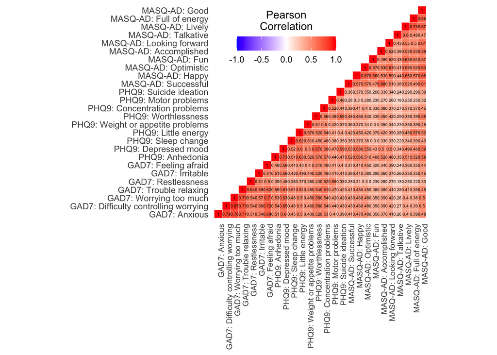

```r
cormat <- round(cor(cfa_data.clean[,2:27],use="complete.obs"),2) #removed !is.na function and added 'use="complete.obs"' instead - correlations worryingly high with !is.na version

upper_tri <- get_upper_tri(cormat)

# Melt the correlation matrix
melted_cormat <- melt(upper_tri, na.rm = TRUE)

#shortened labels for correlation plot
coord_plot_labels <- c("GAD7: Anxious", "GAD7: Difficulty controlling worrying","GAD7: Worrying too much", "GAD7: Trouble relaxing", "GAD7: Restlessness","GAD7: Irritable","GAD7: Feeling afraid", "PHQ9: Anhedonia", "PHQ9: Depressed mood", "PHQ9: Sleep change", "PHQ9: Little energy", "PHQ9: Weight or appetite problems", "PHQ9: Worthlessness", "PHQ9: Concentration problems", "PHQ9: Motor problems", "PHQ9: Suicide ideation", "MASQ-AD: Successful", "MASQ-AD: Happy", "MASQ-AD: Optimistic", "MASQ-AD: Fun", "MASQ-AD: Accomplished", "MASQ-AD: Looking forward", "MASQ-AD: Talkative", "MASQ-AD: Lively", "MASQ-AD: Full of energy", "MASQ-AD: Good")

# Create a ggheatmap
ggheatmap <- ggplot(melted_cormat, aes(Var2, Var1, fill = value))+
 geom_tile(color = "white")+
 scale_fill_gradient2(low = "blue", high = "red", mid = "white",
   midpoint = 0, limit = c(-1,1), space = "Lab",
    name="Pearson\nCorrelation") +
  theme_minimal()+ # minimal theme
 theme(axis.text.x = element_text(angle = 90, vjust = 1,
    size = 8, hjust = 1))+
  scale_x_discrete(label=coord_plot_labels) +
  scale_y_discrete(label=coord_plot_labels) +
 coord_fixed()

ggheatmap <- ggheatmap +
geom_text(aes(Var2, Var1, label = value), color = "black", size = 1.5) +
theme(
  axis.title.x = element_blank(),
  axis.title.y = element_blank(),
  panel.grid.major = element_blank(),
  panel.border = element_blank(),
  panel.background = element_blank(),
  axis.ticks = element_blank(),
  legend.justification = c(1, 0),
  legend.position = c(0.6, 0.7),
  legend.direction = "horizontal")+
  guides(fill = guide_colorbar(barwidth = 7, barheight = 1,
                title.position = "top", title.hjust = 0.5))


print(ggheatmap)
```

```r
ggsave(filename=file.path(dirname(dirname(getwd())),"output/supplementary_tables_figures/CFA_correlations.png"),
       plot=ggheatmap)
```

```r
min(melted_cormat$value)
```

```
[1] 0.18
```

```r
melted_cormat[(melted_cormat$value == 0.63),]
```

|  | Var1 | Var2 | value |
| --- | --- | --- | --- |
| 211 | gad7.pandemic_worry_too_much_.Wave_0 | phq9.pandemic_down_depressed_hopeless_.Wave_0 | 0.63 |
| 268 | phq9.pandemic_little_interest_or_pleasure_.Wave_0 | phq9.pandemic_feel_tired_little_energy_.Wave_0 | 0.63 |
| 565 | masq.pandemic_felt_optimistic_.Wave_0 | masq.pandemic_forward_lot_felt_.Wave_0 | 0.63 |
| 618 | masq.pandemic_lot_felt_fun_.Wave_0 | masq.pandemic_felt_really_up_or_lively_.Wave_0 | 0.63 |
| 669 | masq.pandemic_felt_optimistic_.Wave_0 | masq.pandemic_felt_really_good_about_myself_.Wave_0 | 0.63 |

# CFA

## a priori model specficiation

What items will work best for the tripartite: specify the model

*Item pool* gad7.pandemic_nervous_anxious_on_edge gad7.pandemic_cant_control_worry gad7.pandemic_worry_too_much gad7.pandemic_trouble_relaxing gad7.pandemic_restless gad7.pandemic_easily_annoyed gad7.pandemic_afraid_something_terrible_will_happen phq9.pandemic_little_interest_or_pleasure phq9.pandemic_down_depressed_hopeless phq9.pandemic_trouble_falling_or_staying_asleep phq9.pandemic_feel_tired_little_energy phq9.pandemic_poor_appetite_or_overeating phq9.pandemic_feeling_like_a_failure phq9.pandemic_trouble_concentrating phq9.pandemic_fidgeting_or_moving_slowly phq9.pandemic_thoughts_better_off_dead masq.pandemic_felt_successful masq.pandemic_felt_really_happy masq.pandemic_felt_optimistic masq.pandemic_lot_felt_fun masq.pandemic_felt_like_i_accomplished_a_lot masq.pandemic_forward_lot_felt masq.pandemic_felt_really_talkative masq.pandemic_felt_really_up_or_lively masq.pandemic_lot_felt_energy masq.pandemic_felt_really_good_about_myself

**Kirstin item to factor spec:**

*General distress* gad7.pandemic_nervous_anxious_on_edge gad7.pandemic_cant_control_worry gad7.pandemic_worry_too_much gad7.pandemic_easily_annoyed gad7.pandemic_afraid_something_terrible_will_happen phq9.pandemic_down_depressed_hopeless phq9.pandemic_trouble_falling_or_staying_asleep phq9.pandemic_feel_tired_little_energy phq9.pandemic_poor_appetite_or_overeating phq9.pandemic_feeling_like_a_failure phq9.pandemic_trouble_concentrating phq9.pandemic_thoughts_better_off_dead

*Negative affect (anhedonia)* phq9.pandemic_little_interest_or_pleasure masq.pandemic_felt_successful masq.pandemic_felt_really_happy masq.pandemic_felt_optimistic masq.pandemic_lot_felt_fun masq.pandemic_felt_like_i_accomplished_a_lot masq.pandemic_forward_lot_felt masq.pandemic_felt_really_talkative masq.pandemic_felt_really_up_or_lively masq.pandemic_lot_felt_energy masq.pandemic_felt_really_good_about_myself

*physiological arousal* gad7.pandemic_restless gad7.pandemic_trouble_relaxing phq9.pandemic_fidgeting_or_moving_slowly

**Katie item to factor spec** *General distress* gad7.pandemic_cant_control_worry gad7.pandemic_worry_too_much gad7.pandemic_easily_annoyed gad7.pandemic_afraid_something_terrible_will_happen phq9.pandemic_down_depressed_hopeless phq9.pandemic_trouble_falling_or_staying_asleep phq9.pandemic_feel_tired_little_energy phq9.pandemic_poor_appetite_or_overeating phq9.pandemic_feeling_like_a_failure phq9.pandemic_trouble_concentrating phq9.pandemic_thoughts_better_off_dead phq9.pandemic_fidgeting_or_moving_slowly

*Negative affect (anhedonia)* phq9.pandemic_little_interest_or_pleasure masq.pandemic_felt_successful masq.pandemic_felt_really_happy masq.pandemic_felt_optimistic masq.pandemic_lot_felt_fun masq.pandemic_felt_like_i_accomplished_a_lot masq.pandemic_forward_lot_felt masq.pandemic_felt_really_talkative masq.pandemic_felt_really_up_or_lively masq.pandemic_lot_felt_energy masq.pandemic_felt_really_good_about_myself

*physiological arousal* gad7.pandemic_restless gad7.pandemic_trouble_relaxing gad7.pandemic_nervous_anxious_on_edge

*Differences: (1) nervous, anxious and on edge (Katie Phys arousal, Kirstin general distress), (2) fidgeting or moving slowly (Katie general distress, Kirstin Physiological arousal)*

**Final item to factor spec after consulting on any differences** (still being confirmed. Consulting with others and reading papers to align as closely as possible with theory)

*General distress* gad7.pandemic_cant_control_worry gad7.pandemic_worry_too_much gad7.pandemic_easily_annoyed gad7.pandemic_afraid_something_terrible_will_happen phq9.pandemic_down_depressed_hopeless phq9.pandemic_trouble_falling_or_staying_asleep phq9.pandemic_feel_tired_little_energy phq9.pandemic_poor_appetite_or_overeating phq9.pandemic_feeling_like_a_failure phq9.pandemic_trouble_concentrating phq9.pandemic_thoughts_better_off_dead

*Negative affect (anhedonia)* phq9.pandemic_little_interest_or_pleasure masq.pandemic_felt_successful masq.pandemic_felt_really_happy masq.pandemic_felt_optimistic masq.pandemic_lot_felt_fun masq.pandemic_felt_like_i_accomplished_a_lot masq.pandemic_forward_lot_felt masq.pandemic_felt_really_talkative masq.pandemic_felt_really_up_or_lively masq.pandemic_lot_felt_energy masq.pandemic_felt_really_good_about_myself

## specify the CFA in lavaan

```r
tripartite_model <- 'General_distress =~ gad7.pandemic_cant_control_worry_.Wave_0 + gad7.pandemic_worry_too_much_.Wave_0 + gad7.pandemic_easily_annoyed_.Wave_0 + gad7.pandemic_afraid_something_terrible_will_happen_.Wave_0 + phq9.pandemic_down_depressed_hopeless_.Wave_0 + phq9.pandemic_trouble_falling_or_staying_asleep_.Wave_0 + phq9.pandemic_feel_tired_little_energy_.Wave_0 + phq9.pandemic_poor_appetite_or_overeating_.Wave_0 + phq9.pandemic_feeling_like_a_failure_.Wave_0 + phq9.pandemic_trouble_concentrating_.Wave_0 + phq9.pandemic_thoughts_better_off_dead_.Wave_0

negative_affect =~ masq.pandemic_felt_successful_.Wave_0 + masq.pandemic_felt_really_happy_.Wave_0 + masq.pandemic_felt_optimistic_.Wave_0 + masq.pandemic_lot_felt_fun_.Wave_0 + masq.pandemic_felt_like_i_accomplished_a_lot_.Wave_0 + masq.pandemic_forward_lot_felt_.Wave_0 + masq.pandemic_felt_really_talkative_.Wave_0 + masq.pandemic_felt_really_up_or_lively_.Wave_0 + masq.pandemic_lot_felt_energy_.Wave_0 + masq.pandemic_felt_really_good_about_myself_.Wave_0 + phq9.pandemic_little_interest_or_pleasure_.Wave_0

anxious_arousal =~  + gad7.pandemic_restless_.Wave_0 + gad7.pandemic_trouble_relaxing_.Wave_0 + phq9.pandemic_fidgeting_or_moving_slowly_.Wave_0 + gad7.pandemic_nervous_anxious_on_edge_.Wave_0'


twofactor_model <- 'negative_affect =~ gad7.pandemic_cant_control_worry_.Wave_0 + gad7.pandemic_worry_too_much_.Wave_0 + gad7.pandemic_easily_annoyed_.Wave_0 + gad7.pandemic_afraid_something_terrible_will_happen_.Wave_0 + phq9.pandemic_down_depressed_hopeless_.Wave_0 + phq9.pandemic_trouble_falling_or_staying_asleep_.Wave_0 + phq9.pandemic_feel_tired_little_energy_.Wave_0 + phq9.pandemic_poor_appetite_or_overeating_.Wave_0 + phq9.pandemic_feeling_like_a_failure_.Wave_0 + phq9.pandemic_trouble_concentrating_.Wave_0 + phq9.pandemic_thoughts_better_off_dead_.Wave_0 + gad7.pandemic_nervous_anxious_on_edge_.Wave_0 + gad7.pandemic_restless_.Wave_0 + gad7.pandemic_trouble_relaxing_.Wave_0 + phq9.pandemic_fidgeting_or_moving_slowly_.Wave_0

positive_affect =~ masq.pandemic_felt_successful_.Wave_0 + masq.pandemic_felt_really_happy_.Wave_0 + masq.pandemic_felt_optimistic_.Wave_0 + masq.pandemic_lot_felt_fun_.Wave_0 + masq.pandemic_felt_like_i_accomplished_a_lot_.Wave_0 + masq.pandemic_forward_lot_felt_.Wave_0 + masq.pandemic_felt_really_talkative_.Wave_0 + masq.pandemic_felt_really_up_or_lively_.Wave_0 + masq.pandemic_lot_felt_energy_.Wave_0 + masq.pandemic_felt_really_good_about_myself_.Wave_0 + phq9.pandemic_little_interest_or_pleasure_.Wave_0 '
```

```r
fit.tri <- cfa(tripartite_model, data=cfa_data.clean)
```

```r
fit.two <- cfa(twofactor_model, data=cfa_data.clean)
```

```r
summary(fit.tri,fit.measures = TRUE,standardized=TRUE)
```

```
lavaan 0.6-8 ended normally after 40 iterations

  Estimator                                         ML
  Optimization method                           NLMINB
  Number of model parameters                        55

                                                  Used       Total
  Number of observations                          8589       10900

Model Test User Model:

  Test statistic                              24123.869
  Degrees of freedom                                296
  P-value (Chi-square)                            0.000

Model Test Baseline Model:

  Test statistic                            158734.159
  Degrees of freedom                               325
  P-value                                        0.000

User Model versus Baseline Model:

  Comparative Fit Index (CFI)                    0.850
  Tucker-Lewis Index (TLI)                       0.835

Loglikelihood and Information Criteria:

  Loglikelihood user model (H0)            -261566.220
  Loglikelihood unrestricted model (H1)    -249504.285

  Akaike (AIC)                              523242.440
  Bayesian (BIC)                            523630.643
  Sample-size adjusted Bayesian (BIC)       523455.863

Root Mean Square Error of Approximation:

  RMSEA                                          0.097
  90 Percent confidence interval - lower         0.096
  90 Percent confidence interval - upper         0.098
```

[output cut: 68 more lines]

```
   .msq.pn____.W_0    0.500    0.008   61.001    0.000    0.500    0.484
   .ms._______.W_0    0.704    0.012   61.175    0.000    0.704    0.494
   .msq.pn____.W_0    0.703    0.012   60.900    0.000    0.703    0.478
   .msq.pn____.W_0    0.815    0.013   63.404    0.000    0.815    0.666
   .msq.______.W_0    0.375    0.006   57.942    0.000    0.375    0.359
   .msq.pn____.W_0    0.502    0.008   59.995    0.000    0.502    0.434
   .msq.______.W_0    0.376    0.007   55.670    0.000    0.376    0.302
   .phq9._____.W_0    0.539    0.009   61.417    0.000    0.539    0.508
   .gd7.pndm__.W_0    0.484    0.008   61.157    0.000    0.484    0.538
   .gd7.pnd___.W_0    0.308    0.006   50.193    0.000    0.308    0.271
   .phq9._____.W_0    0.482    0.008   62.955    0.000    0.482    0.660
   .gd7.p_____.W_0    0.347    0.006   53.544    0.000    0.347    0.315
    General_dstrss    0.880    0.018   49.765    0.000    1.000    1.000
    negative_affct    0.609    0.016   37.829    0.000    1.000    1.000
    anxious_arousl    0.417    0.012   34.898    0.000    1.000    1.000
```

```r
summary(fit.two,fit.measures = TRUE,standardized=TRUE)
```

```
lavaan 0.6-8 ended normally after 32 iterations

  Estimator                                         ML
  Optimization method                           NLMINB
  Number of model parameters                        53

                                                  Used       Total
  Number of observations                          8589       10900

Model Test User Model:

  Test statistic                              24623.648
  Degrees of freedom                                298
  P-value (Chi-square)                            0.000

Model Test Baseline Model:

  Test statistic                            158734.159
  Degrees of freedom                               325
  P-value                                        0.000

User Model versus Baseline Model:

  Comparative Fit Index (CFI)                    0.846
  Tucker-Lewis Index (TLI)                       0.833

Loglikelihood and Information Criteria:

  Loglikelihood user model (H0)            -261816.109
  Loglikelihood unrestricted model (H1)    -249504.285

  Akaike (AIC)                              523738.219
  Bayesian (BIC)                            524112.305
  Sample-size adjusted Bayesian (BIC)       523943.881

Root Mean Square Error of Approximation:

  RMSEA                                          0.097
  90 Percent confidence interval - lower         0.096
  90 Percent confidence interval - upper         0.099
```

[output cut: 63 more lines]

```
   .gd7.pnd___.W_0    0.351    0.006   58.441    0.000    0.351    0.308
   .phq9._____.W_0    0.490    0.008   63.984    0.000    0.490    0.670
   .msq.pnd___.W_0    0.570    0.009   60.979    0.000    0.570    0.484
   .msq.pn____.W_0    0.384    0.007   57.545    0.000    0.384    0.349
   .msq.pnd___.W_0    0.459    0.008   59.348    0.000    0.459    0.409
   .msq.pn____.W_0    0.498    0.008   60.926    0.000    0.498    0.481
   .ms._______.W_0    0.706    0.012   61.174    0.000    0.706    0.495
   .msq.pn____.W_0    0.702    0.012   60.866    0.000    0.702    0.478
   .msq.pn____.W_0    0.814    0.013   63.380    0.000    0.814    0.665
   .msq.______.W_0    0.372    0.006   57.822    0.000    0.372    0.357
   .msq.pn____.W_0    0.503    0.008   59.978    0.000    0.503    0.435
   .msq.______.W_0    0.377    0.007   55.671    0.000    0.377    0.303
   .phq9._____.W_0    0.543    0.009   61.458    0.000    0.543    0.512
    negative_affct    0.894    0.018   50.443    0.000    1.000    1.000
    positive_affct    0.607    0.016   37.751    0.000    1.000    1.000
```